# R Notebook

## Prob 1

#

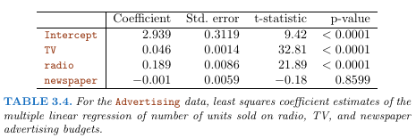

Null-hypotheses: TV, radio, and newspaper advertising spending has no effect on the number of units sold.

Conclusions: TV and radio have a significant effect on unit sales with p-values < 0.01. Newspaper advertising has an insignificant effect on unit sales.

## Prob 2

KNN classifier is used in qualitative cases. It is a simple statistical model looking at the identity of nearby points to classify the point of interest.

KNN regression uses nearby points to create a linear or other form regression for the local area based on the surronding points. This is done at every point in the data set.

## Prob 3

Equation

$$\textrm{Salary} = 50 + 20 X_1 + 0.07 X_2 + 35 X_3 + 0.01 X_4 - 10 X_5$$
a. iii is correct. If $|\hat{\beta}_5 * X_1| > \hat{\beta}_3$ then males will earn more than females since all other coefficients and predictors are positive.

2. $137.1 * 10^{3}$
3. False, there can still be an interaction effect even with a small coefficient. Since the product of GPA and IQ is likely in the $10^2$ range, this effect can be significant even with a small coefficient. Looking at the p-value would be more beneficial the the value of the coefficient.

## Prob 4

1. If it is truly linear relationship, it would be expected that the linear and cubic regression would be the same as the optimal value would be setting $\beta_2 = \beta+3 = 0$ to get a perfect fit.
2. As the relationship is truly linear, the same relationship should hold.
3. It would be expected that the RSS for the cubic regression would be lower than the linear case. The sum least squares is at most equal to the linear case is likely less due to the presence of more fitting variables.
4. There is not enough information to answer. The cubic could be significantly worse than linear depending on the actual form of the relationship.

## Prob 5

Let
$$a_{i} = \frac{x_i}{\sum_{i'=1}^{n} x_{i'}^2}$$
such that
$$\hat{y}_i = \sum_{i'=1}^{n} a_{i'}y_{i'}$$

## Prob 6

Equation 3.4 states

$$\hat{\beta}_0 = \bar{y} - \hat{\beta}_1 \bar{x}$$

The least squares line is

$$y = \hat{\beta}_0 + \hat{\beta}_1 x$$

Using Eq 3.4 to substitute for $\hat{\beta}_0$

$$y - \bar{y} = \hat{\beta}_1 (x-\bar{x})$$

At $(x,y) = (\bar{x},\bar{y})$, this reduces to

$$0 = 0$$

showing that $(\bar{x},\bar{y})$ lies on the least squares line. ## Prob 7

$$\sum y_i^2 - 2 y_i \bar{y} + \bar{y}^2 - y_i^2 +2 y_i \hat{y}_i - \hat{y}_i^2$$

$$\sum 2 y_i (\hat{y}_i-\bar{y}) + \bar{y}^2 + \hat{y}_i^2$$
## Prob 8

```r
library("ISLR")
auto.fit = lm(mpg~horsepower,data=Auto)
summary(auto.fit)
```

```
Call:
lm(formula = mpg ~ horsepower, data = Auto)

Residuals:
     Min       1Q   Median       3Q      Max
-13.5710  -3.2592  -0.3435   2.7630  16.9240

Coefficients:
             Estimate Std. Error t value Pr(>|t|)
(Intercept) 39.935861   0.717499   55.66   <2e-16 ***
horsepower  -0.157845   0.006446  -24.49   <2e-16 ***
---
Signif. codes:  0 ‘***’ 0.001 ‘**’ 0.01 ‘*’ 0.05 ‘.’ 0.1 ‘ ’ 1

Residual standard error: 4.906 on 390 degrees of freedom
  (5 observations deleted due to missingness)
Multiple R-squared:  0.6059,    Adjusted R-squared:  0.6049
F-statistic: 599.7 on 1 and 390 DF,  p-value: < 2.2e-16
```

1. Yes the p-value is much less than 0.001 indicating the fit is significant.
2. Each unit increase in horsepower reduces mpg by 0.158.
3. negative

```r
predict (auto.fit, data.frame(horsepower = c(98)) ,interval ="confidence")
```

```
       fit      lwr      upr
1 24.46708 23.97308 24.96108
```

```r
predict (auto.fit, data.frame(horsepower = c(98)) ,interval ="prediction")
```

```
       fit     lwr      upr
1 24.46708 14.8094 34.12476
```

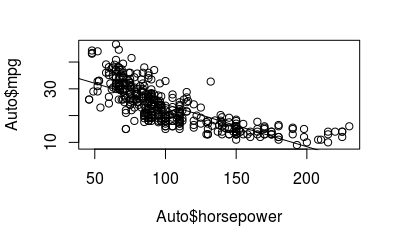

```r
plot(Auto$horsepower,Auto$mpg)
abline(auto.fit)
```

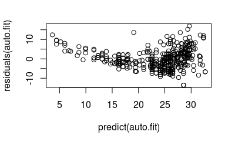

```r
plot(predict(auto.fit),residuals(auto.fit))
```

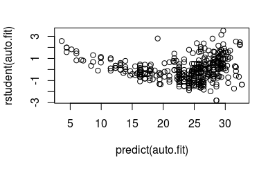

```r
plot(predict(auto.fit),rstudent(auto.fit))
```

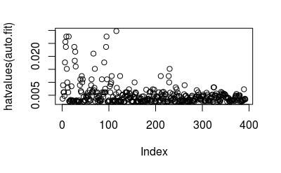

```r
plot(hatvalues(auto.fit))
```

## Prob 9

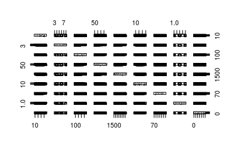

```r
pairs(Auto)
```

```r
cor(Auto[,!(colnames(Auto) == "name")])
```

```
                    mpg  cylinders displacement horsepower     weight acceleration       year     origin
mpg           1.0000000 -0.7762599   -0.8044430         NA -0.8317389    0.4222974  0.5814695  0.5636979
cylinders    -0.7762599  1.0000000    0.9509199         NA  0.8970169   -0.5040606 -0.3467172 -0.5649716
displacement -0.8044430  0.9509199    1.0000000         NA  0.9331044   -0.5441618 -0.3698041 -0.6106643
horsepower           NA         NA           NA          1         NA           NA         NA         NA
weight       -0.8317389  0.8970169    0.9331044         NA  1.0000000   -0.4195023 -0.3079004 -0.5812652
acceleration  0.4222974 -0.5040606   -0.5441618         NA -0.4195023    1.0000000  0.2829009  0.2100836
year          0.5814695 -0.3467172   -0.3698041         NA -0.3079004    0.2829009  1.0000000  0.1843141
origin        0.5636979 -0.5649716   -0.6106643         NA -0.5812652    0.2100836  0.1843141  1.0000000
```

```r
lmautofit = lm(mpg~.-name,data=Auto)
summary(lmautofit)
```

```
Call:
lm(formula = mpg ~ . - name, data = Auto)

Residuals:
    Min      1Q  Median      3Q     Max
-9.5903 -2.1565 -0.1169  1.8690 13.0604

Coefficients:
               Estimate Std. Error t value Pr(>|t|)
(Intercept)  -17.218435   4.644294  -3.707  0.00024 ***
cylinders     -0.493376   0.323282  -1.526  0.12780
displacement   0.019896   0.007515   2.647  0.00844 **
horsepower    -0.016951   0.013787  -1.230  0.21963
weight        -0.006474   0.000652  -9.929  < 2e-16 ***
acceleration   0.080576   0.098845   0.815  0.41548
year           0.750773   0.050973  14.729  < 2e-16 ***
origin         1.426141   0.278136   5.127 4.67e-07 ***
---
Signif. codes:  0 ‘***’ 0.001 ‘**’ 0.01 ‘*’ 0.05 ‘.’ 0.1 ‘ ’ 1

Residual standard error: 3.328 on 384 degrees of freedom
  (5 observations deleted due to missingness)
Multiple R-squared:  0.8215,    Adjusted R-squared:  0.8182
F-statistic: 252.4 on 7 and 384 DF,  p-value: < 2.2e-16
```

1. Yes the p-value is < 2.2e-16 indicating a significant correlation between predictor and response.
2. weight, year, origin, and displacement are significant factors for mpg
3. With increasing model year, the mpg increases by approximately 0.75 mpg for each year.

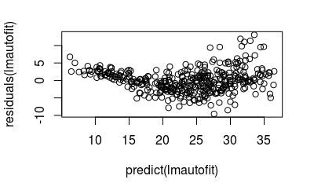

```r
plot(predict(lmautofit),residuals(lmautofit))
```

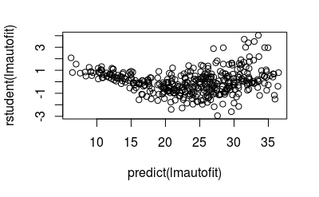

```r
plot(predict(lmautofit),rstudent(lmautofit))
```

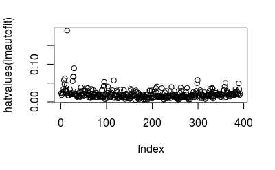

```r
plot(hatvalues(lmautofit))
```

There is an increase in spread at higher mpg values as well as a non-linear trend in a u-shape curve through the residuals.

```r
lmautofit = lm(mpg~.-name+horsepower*weight+cylinders:weight,data=Auto)
summary(lmautofit)
```

```
Call:
lm(formula = mpg ~ . - name + horsepower * weight + cylinders:weight,
    data = Auto)

Residuals:
    Min      1Q  Median      3Q     Max
-8.9409 -1.6129 -0.2188  1.5948 12.0255

Coefficients:
                    Estimate Std. Error t value Pr(>|t|)
(Intercept)        4.466e+00  4.893e+00   0.913  0.36194
cylinders         -8.453e-01  1.012e+00  -0.835  0.40414
displacement       6.978e-03  6.862e-03   1.017  0.30984
horsepower        -2.070e-01  3.734e-02  -5.544 5.51e-08 ***
weight            -1.205e-02  1.234e-03  -9.764  < 2e-16 ***
acceleration      -6.556e-02  9.331e-02  -0.703  0.48272
year               7.722e-01  4.507e-02  17.133  < 2e-16 ***
origin             8.042e-01  2.540e-01   3.166  0.00167 **
horsepower:weight  4.840e-05  9.722e-06   4.978 9.73e-07 ***
cylinders:weight   2.513e-04  2.989e-04   0.841  0.40099
---
Signif. codes:  0 ‘***’ 0.001 ‘**’ 0.01 ‘*’ 0.05 ‘.’ 0.1 ‘ ’ 1

Residual standard error: 2.932 on 382 degrees of freedom
  (5 observations deleted due to missingness)
Multiple R-squared:  0.8621,    Adjusted R-squared:  0.8588
F-statistic: 265.3 on 9 and 382 DF,  p-value: < 2.2e-16
```

## Prob 10

```r
lmfitcar = lm(Sales~Price+Urban+US,data=Carseats)
summary(lmfitcar)
```

```
Call:
lm(formula = Sales ~ Price + Urban + US, data = Carseats)

Residuals:
    Min      1Q  Median      3Q     Max
-6.9206 -1.6220 -0.0564  1.5786  7.0581

Coefficients:
             Estimate Std. Error t value Pr(>|t|)
(Intercept) 13.043469   0.651012  20.036  < 2e-16 ***
Price       -0.054459   0.005242 -10.389  < 2e-16 ***
UrbanYes    -0.021916   0.271650  -0.081    0.936
USYes        1.200573   0.259042   4.635 4.86e-06 ***
---
Signif. codes:  0 ‘***’ 0.001 ‘**’ 0.01 ‘*’ 0.05 ‘.’ 0.1 ‘ ’ 1

Residual standard error: 2.472 on 396 degrees of freedom
Multiple R-squared:  0.2393,    Adjusted R-squared:  0.2335
F-statistic: 41.52 on 3 and 396 DF,  p-value: < 2.2e-16
```

2. Price and US are significant for the model while Urban is insignificant for predicting sales. Price has an indirect relationship with Sales. Sales go up by 1.2 thousand if the store is in the United States in the United States.
3. $$S = \beta_0 + \beta_1 P + \beta_2 x_{urb} + \beta_3 x_{us}$$
   with
   $$x_{urb} = \cases{
   1 & \text{if Urban is Yes}\cr
   0 & \text{otherwise}
   }$$

and
$$x_{us} = \cases{
1 & \text{if US is Yes}\cr
0 & \text{otherwise}
}$$

4. For all but $\beta_2$.

```r
summary(lmfitcar)
```

[output not shown]

6. The models are pretty close to each other (e) is a bit better adjusted R-squared

```r
confint(lmfitcar,level=0.95)
```

[output not shown]

```r
which.max(hatvalues(lmfitcar))
```

```
43
43
```

## Prob 11

```r
set.seed(1)
x=rnorm(100)
y=2*x+rnorm(100)
```

```r
lmfit11 = lm(y~x+0)
summary(lmfit11)
```

```
Call:
lm(formula = y ~ x + 0)

Residuals:
    Min      1Q  Median      3Q     Max
-1.9154 -0.6472 -0.1771  0.5056  2.3109

Coefficients:
  Estimate Std. Error t value Pr(>|t|)
x   1.9939     0.1065   18.73   <2e-16 ***
---
Signif. codes:
0 ‘***’ 0.001 ‘**’ 0.01 ‘*’ 0.05 ‘.’ 0.1 ‘ ’ 1

Residual standard error: 0.9586 on 99 degrees of freedom
Multiple R-squared:  0.7798,    Adjusted R-squared:  0.7776
F-statistic: 350.7 on 1 and 99 DF,  p-value: < 2.2e-16
```

Coefficient $\hat{\beta}$ associated with $x$ is fit to be 1.9939 with a t-value of 18.73 and p-value of <2e-16. This is sufficient to reject the null hypothesis.

```r
lmfit11b = lm(x~y+0)
summary(lmfit11b)
```

```
Call:
lm(formula = x ~ y + 0)

Residuals:
    Min      1Q  Median      3Q     Max
-0.8699 -0.2368  0.1030  0.2858  0.8938

Coefficients:
  Estimate Std. Error t value Pr(>|t|)
y  0.39111    0.02089   18.73   <2e-16 ***
---
Signif. codes:
0 ‘***’ 0.001 ‘**’ 0.01 ‘*’ 0.05 ‘.’ 0.1 ‘ ’ 1

Residual standard error: 0.4246 on 99 degrees of freedom
Multiple R-squared:  0.7798,    Adjusted R-squared:  0.7776
F-statistic: 350.7 on 1 and 99 DF,  p-value: < 2.2e-16
```

## Prob 12

1. When the
   $$\sum_{i' = 1}^n x_{i'}^2 = \sum_{i' = 1}^n y_{i'}^2$$

```r
x = rnorm(99)
y = rnorm(99)
x=c(x,0)
y=c(y,(sum(x^2) - sum(y^2))^.5)
sum(x^2) - sum(y^2)
```

```
[1] NaN
```